# PML Final Project

Joe DeMaro

9/11/2019

## Abstract

Data from IoT devices for fitness collect an enormous amount of data about an individuals personal activities. For this analysis, data from 6 individuals performing barbell lifts in a variety of correct and incorrect fashions was collected.

The task for the analyst is to predict the manner in which a user did the exercise. The given data consists or a training and a test group. The data from both groups is cleaned and analyzed in a variety of fashions to determine the best model for prediction. The provided test set is held until the best model is created. The training set is divided into a training and testing set to help determine the best model.

### Download Source Data

```r
## load training data
training = read_csv(url("https://d396qusza40orc.cloudfront.net/predmachlearn/pml-training.csv"))
dim(training)
```

```
## [1] 19622   160
```

```r
## load test data
testing <- read_csv(url("https://d396qusza40orc.cloudfront.net/predmachlearn/pml-testing.csv"))
dim(testing)
```

```
## [1]  20 160
```

####1. Velloso, E.; Bulling, A.; Gellersen, H.; Ugulino, W.; Fuks, H. Qualitative Activity Recognition of Weight Lifting Exercises. Proceedings of 4th International Conference in Cooperation with SIGCHI (Augmented Human ’13) . Stuttgart, Germany: ACM SIGCHI, 2013

### Clean Training Data

#### Columns with over 90% NA or blank are removed from analysis. The the 1st 7 columns are not data but description fields. They are eliminated from training data and from final testing data below.

```r
indColToRemove <- which(colSums(is.na(training) | training=="")>0.9*dim(training)[1])
training_clean <- training[,-indColToRemove]
training_clean <- training_clean[,-c(1:7)]
dim(training_clean)
```

```
## [1] 19622    53
```

### Clean Model Verification Data

#### final_clean data is processed the same as the training set above but is reserved until the best, most accurate model is realized.

```r
indColToRemove <- which(colSums(is.na(testing) | testing=="")>0.9*dim(testing)[1])
final_clean <- testing[,-indColToRemove]
final_clean <- final_clean[,-c(1:7)]
dim(final_clean)
```

```
## [1] 20 53
```

### Create Training and Testing Data Set

#### Make Training and Testing Set from the Training Data downloaded from source(1). This testing set is different than testing set provided from source(1) and used to test the different models. The testing data from source will be used with final model to validate that model. 70% of the training data was used to create the model training data, 30% was reserved for testing.

```r
set.seed(12345)
## Get training data
inTrain <- createDataPartition(training_clean$classe, p = 0.7, list = FALSE)
trainData <- training_clean[inTrain, ]
dim(trainData)
```

```
## [1] 13737    53
```

```r
#Get Test Set
testData <- training_clean[-inTrain, ]
dim(testData)
```

```
## [1] 5885   53
```

### Correlation Analysis

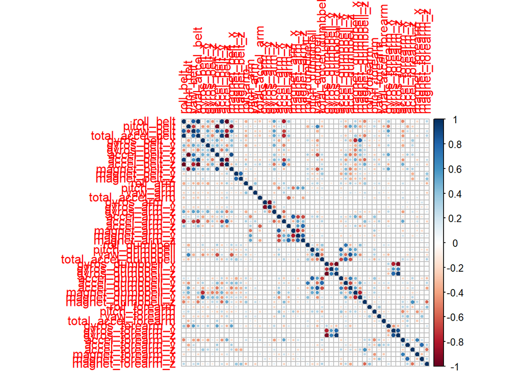

```r
corr_data <- cor(trainData[, -53])
corrplot(corr_data, method="circle")
```

```r
## find highly correlated columns
highCor <- findCorrelation(corr_data, cutoff = 0.80)
names(trainData)[highCor]
```

```
##  [1] "accel_belt_z"     "roll_belt"        "accel_belt_y"
##  [4] "accel_dumbbell_z" "accel_belt_x"     "pitch_belt"
##  [7] "accel_arm_x"      "accel_dumbbell_x" "magnet_arm_y"
## [10] "gyros_forearm_y"  "gyros_dumbbell_x" "gyros_dumbbell_z"
## [13] "gyros_arm_x"
```

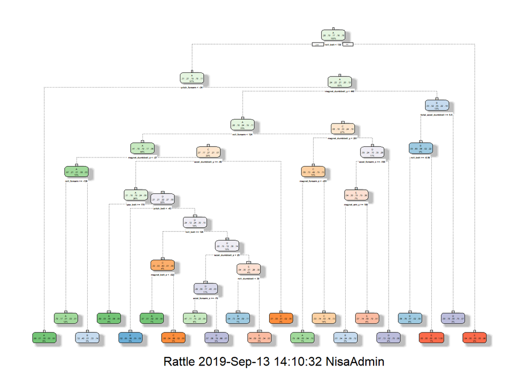

```r
decisionTreeMod1 <- rpart(classe ~ ., data=trainData, method="class")
fancyRpartPlot(decisionTreeMod1)
```

```r
predictTreeMod1 <- predict(decisionTreeMod1, testData, type = "class")

ConMat <- confusionMatrix(factor(predictTreeMod1), factor(testData$classe))
ConMat
```

```
## Confusion Matrix and Statistics
##
##           Reference
## Prediction    A    B    C    D    E
##          A 1498  196   69  106   25
##          B   42  669   85   86   92
##          C   43  136  739  129  131
##          D   33   85   98  553   44
##          E   58   53   35   90  790
##
## Overall Statistics
##
##                Accuracy : 0.722
##                  95% CI : (0.7104, 0.7334)
##     No Information Rate : 0.2845
##     P-Value [Acc > NIR] : < 2.2e-16
##
##                   Kappa : 0.6467
##
##  Mcnemar's Test P-Value : < 2.2e-16
##
## Statistics by Class:
##
##                      Class: A Class: B Class: C Class: D Class: E
## Sensitivity            0.8949   0.5874   0.7203  0.57365   0.7301
## Specificity            0.9060   0.9357   0.9097  0.94717   0.9509
## Pos Pred Value         0.7909   0.6869   0.6273  0.68020   0.7700
## Neg Pred Value         0.9559   0.9043   0.9390  0.91897   0.9399
## Prevalence             0.2845   0.1935   0.1743  0.16381   0.1839
## Detection Rate         0.2545   0.1137   0.1256  0.09397   0.1342
## Detection Prevalence   0.3218   0.1655   0.2002  0.13815   0.1743
## Balanced Accuracy      0.9004   0.7615   0.8150  0.76041   0.8405
```

### Plot Accuracy for Decision Tree

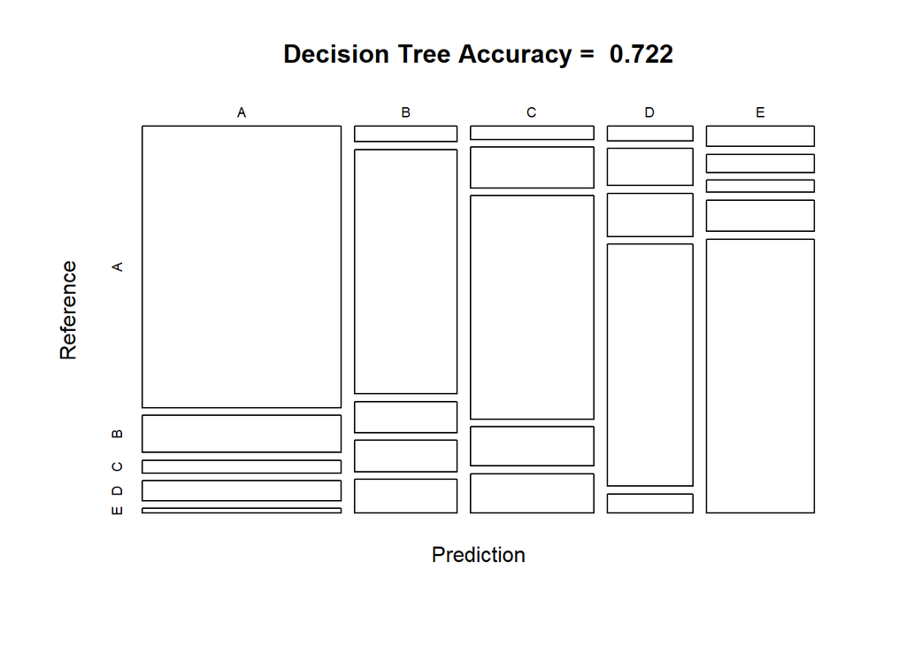

```r
plot(ConMat$table, col=ConMat$byClass,
      main = paste("Decision Tree Accuracy = ", round(ConMat$overall['Accuracy'],4)))
```

## Random Forest Analysis

```r
controlRF <- trainControl(method="cv",number=3, verboseIter = FALSE)
modRF1 <- train(classe ~ ., data=trainData, method="rf", trControl=controlRF)
modRF1$finalModel
```

```
##
## Call:
##  randomForest(x = x, y = y, mtry = param$mtry)
##                Type of random forest: classification
##                      Number of trees: 500
## No. of variables tried at each split: 2
##
##         OOB estimate of  error rate: 0.59%
## Confusion matrix:
##      A    B    C    D    E class.error
## A 3902    2    2    0    0 0.001024066
## B   17 2637    4    0    0 0.007900677
## C    0   18 2376    2    0 0.008347245
## D    0    0   27 2223    2 0.012877442
## E    0    0    1    6 2518 0.002772277
```

## Validate RF model

```r
predictRF1 <- predict(modRF1, newdata=testData)
ConRF <- confusionMatrix(factor(predictRF1), factor(testData$classe))
ConRF
```

```
## Confusion Matrix and Statistics
##
##           Reference
## Prediction    A    B    C    D    E
##          A 1673   12    0    0    0
##          B    1 1123   12    0    0
##          C    0    4 1011   25    0
##          D    0    0    3  939    3
##          E    0    0    0    0 1079
##
## Overall Statistics
##
##                Accuracy : 0.9898
##                  95% CI : (0.9869, 0.9922)
##     No Information Rate : 0.2845
##     P-Value [Acc > NIR] : < 2.2e-16
##
##                   Kappa : 0.9871
##
##  Mcnemar's Test P-Value : NA
##
## Statistics by Class:
##
##                      Class: A Class: B Class: C Class: D Class: E
## Sensitivity            0.9994   0.9860   0.9854   0.9741   0.9972
## Specificity            0.9972   0.9973   0.9940   0.9988   1.0000
## Pos Pred Value         0.9929   0.9886   0.9721   0.9937   1.0000
## Neg Pred Value         0.9998   0.9966   0.9969   0.9949   0.9994
## Prevalence             0.2845   0.1935   0.1743   0.1638   0.1839
## Detection Rate         0.2843   0.1908   0.1718   0.1596   0.1833
## Detection Prevalence   0.2863   0.1930   0.1767   0.1606   0.1833
## Balanced Accuracy      0.9983   0.9916   0.9897   0.9864   0.9986
```

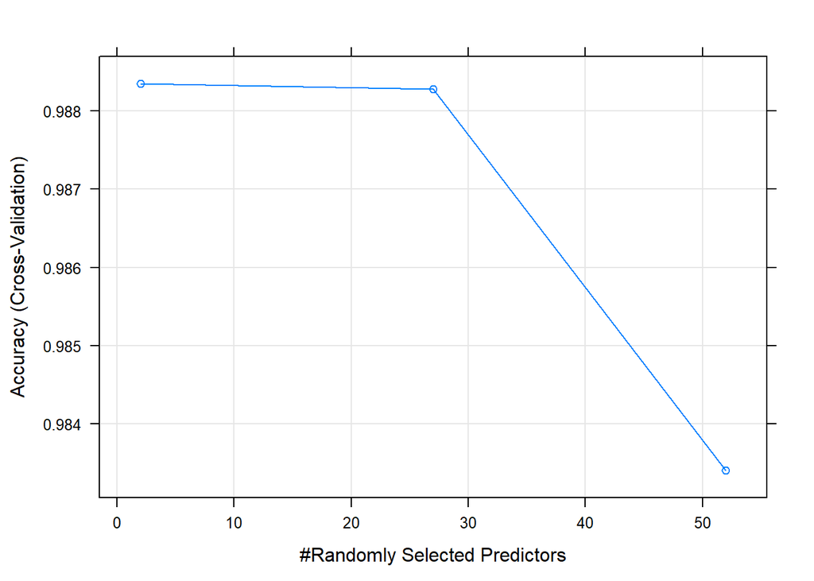

```r
plot(modRF1)
```

### Plot Accuracy of Random Forest Model

#### Accuracy of Random Forest Data is very close to 1 (98.9%).

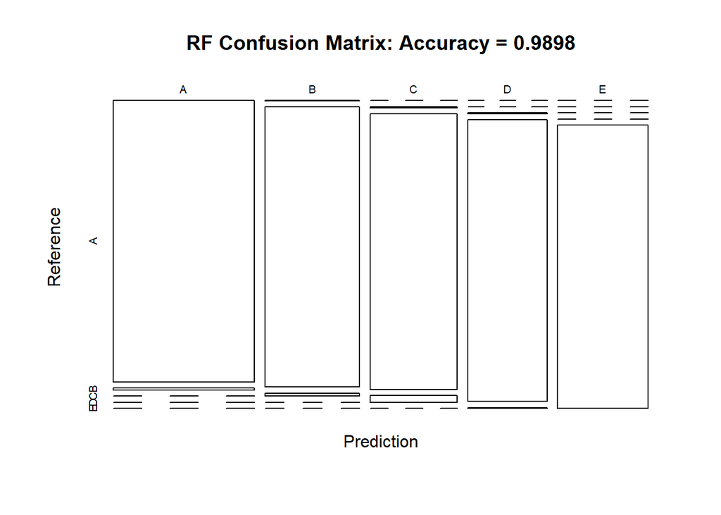

```r
plot(ConRF$table, col=ConRF$byClass, main=paste("RF Confusion Matrix: Accuracy =", round(ConRF$overall['Accuracy'], 4)))
```

### GBM analysis

```r
set.seed(12345)
cGBM <- trainControl(method="repeatedcv", number=5,repeats=1)
modGBM <- train(classe ~ ., data=trainData, method="gbm", trControl=cGBM, verbose=FALSE)
modGBM$finalModel
```

```
## A gradient boosted model with multinomial loss function.
## 150 iterations were performed.
## There were 52 predictors of which 52 had non-zero influence.
```

```r
print(modGBM)
```

```
## Stochastic Gradient Boosting
##
## 13737 samples
##    52 predictor
##     5 classes: 'A', 'B', 'C', 'D', 'E'
##
## No pre-processing
## Resampling: Cross-Validated (5 fold, repeated 1 times)
## Summary of sample sizes: 10990, 10991, 10989, 10990, 10988
## Resampling results across tuning parameters:
##
##   interaction.depth  n.trees  Accuracy   Kappa
##   1                   50      0.7538757  0.6878753
##   1                  100      0.8255071  0.7791232
##   1                  150      0.8578292  0.8200937
##   2                   50      0.8614677  0.8245091
##   2                  100      0.9084218  0.8840935
##   2                  150      0.9316436  0.9134935
##   3                   50      0.8976480  0.8704530
##   3                  100      0.9429994  0.9278664
##   3                  150      0.9617087  0.9515491
##
## Tuning parameter 'shrinkage' was held constant at a value of 0.1
##
## Tuning parameter 'n.minobsinnode' was held constant at a value of 10
## Accuracy was used to select the optimal model using the largest value.
## The final values used for the model were n.trees = 150,
##  interaction.depth = 3, shrinkage = 0.1 and n.minobsinnode = 10.
```

### Validate GBM model

####The confusion matrix for the gbm model places the accuracy at about 96%. Therefore the random forest model is more accurate and will be used in the final validation test.

```r
predictGBM <- predict(modGBM, newdata = testData)

CMgbm <- confusionMatrix(factor(predictGBM), factor(testData$classe))
CMgbm
```

```
## Confusion Matrix and Statistics
##
##           Reference
## Prediction    A    B    C    D    E
##          A 1649   41    0    2    1
##          B   17 1060   34    2   12
##          C    5   32  973   36    8
##          D    3    5   17  919   19
##          E    0    1    2    5 1042
##
## Overall Statistics
##
##                Accuracy : 0.9589
##                  95% CI : (0.9535, 0.9638)
##     No Information Rate : 0.2845
##     P-Value [Acc > NIR] : < 2.2e-16
##
##                   Kappa : 0.948
##
##  Mcnemar's Test P-Value : 1.87e-06
##
## Statistics by Class:
##
##                      Class: A Class: B Class: C Class: D Class: E
## Sensitivity            0.9851   0.9306   0.9483   0.9533   0.9630
## Specificity            0.9896   0.9863   0.9833   0.9911   0.9983
## Pos Pred Value         0.9740   0.9422   0.9231   0.9543   0.9924
## Neg Pred Value         0.9940   0.9834   0.9890   0.9909   0.9917
## Prevalence             0.2845   0.1935   0.1743   0.1638   0.1839
## Detection Rate         0.2802   0.1801   0.1653   0.1562   0.1771
## Detection Prevalence   0.2877   0.1912   0.1791   0.1636   0.1784
## Balanced Accuracy      0.9873   0.9585   0.9658   0.9722   0.9807
```

### Run test data provided in beginning from source.

#### Run test final_clean data against the most accurate model - Random Forest. Results are for twenty (20) test against classe field of data.

```r
Results <- predict(modRF1, newdata = final_clean)
Results
```

```
##  [1] B A B A A E D B A A B C B A E E A B B B
## Levels: A B C D E
```